# Team1

HanqingShi

2016-11-30

# R Score & Time Analysis

## R Score EDA

```
##     Min.  1st Qu.   Median     Mean  3rd Qu.     Max.
##   -8.000    1.000    1.000    2.833    3.000 1058.000
```

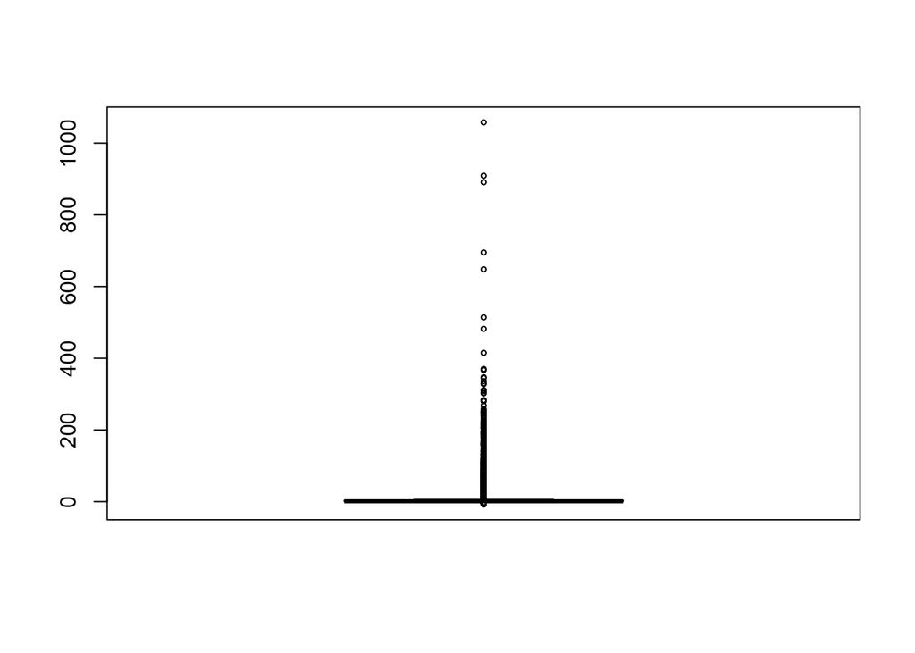

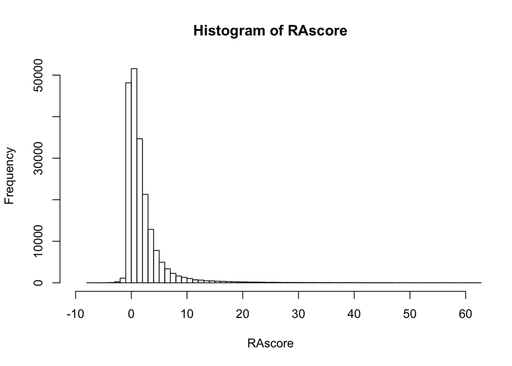

Choose the good answer threshold = 3, the 3rd quantile.

## R Time EDA

Time(hours) = time spent until get a good answer Label = 1, questions get good answers, Label = 0, otherwise.

Total number of questions is 147071. Number of questions with Time=0 is 110. Number of questions never get a good answer is 100636.

```
##    Min. 1st Qu.  Median    Mean 3rd Qu.    Max.
##    0.00   24.97 1894.00 1302.00 1894.00 1894.00
```

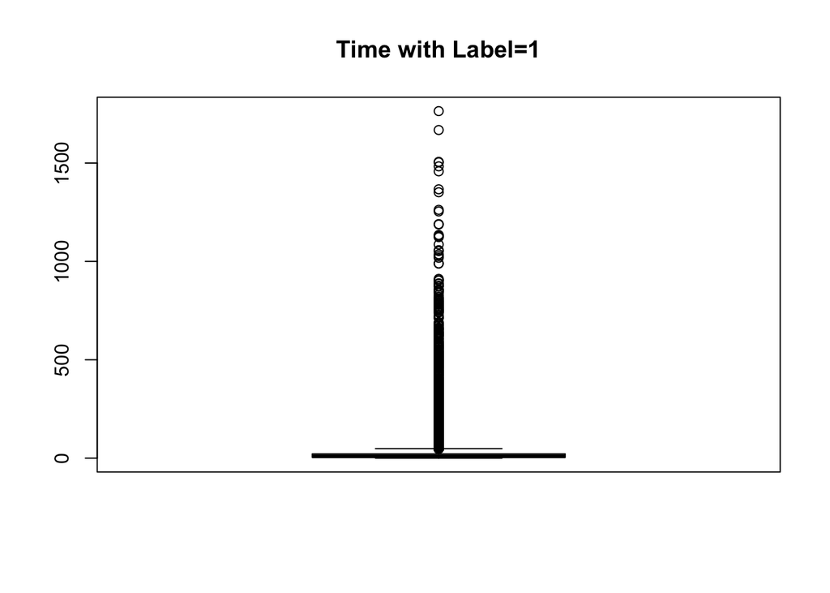

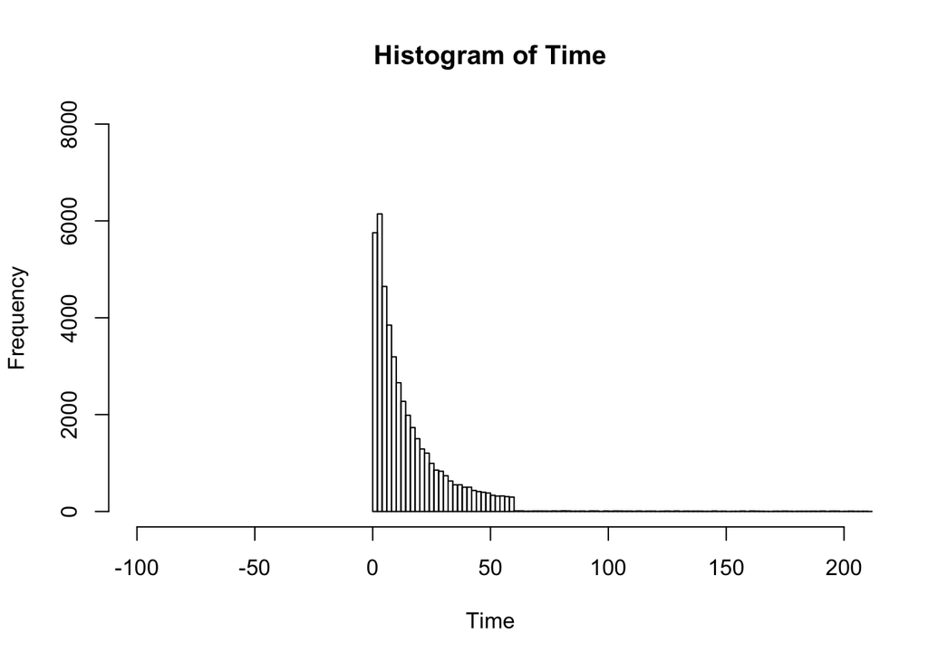

## Random Forest

Score ~ tag_count + max_tag_freq + sum_tag_freq + body_length + title_length + body_word_count + title_word_count + code_blocks_count + code_comments_count + url_count + img_count + code_length + comments_length

MSE = 8.2

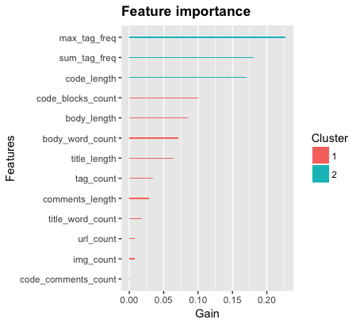

## Logistic Regression

Label prediction: Split data into train(80%) and test(20%), do logistic regression, calculate prediction accuracy.

```
##               Estimate  Std. Error   z value Pr(>|z|)
## (Intercept) -1.7259480 0.009928074 -173.8452        0
## Score        0.6181663 0.004818347  128.2943        0
```

Prediction Accuracy = 0.7927178

## Python Score EDA

```
##     Min.  1st Qu.   Median     Mean  3rd Qu.     Max.
##  -38.000    0.000    1.000    3.028    3.000 8384.000
```

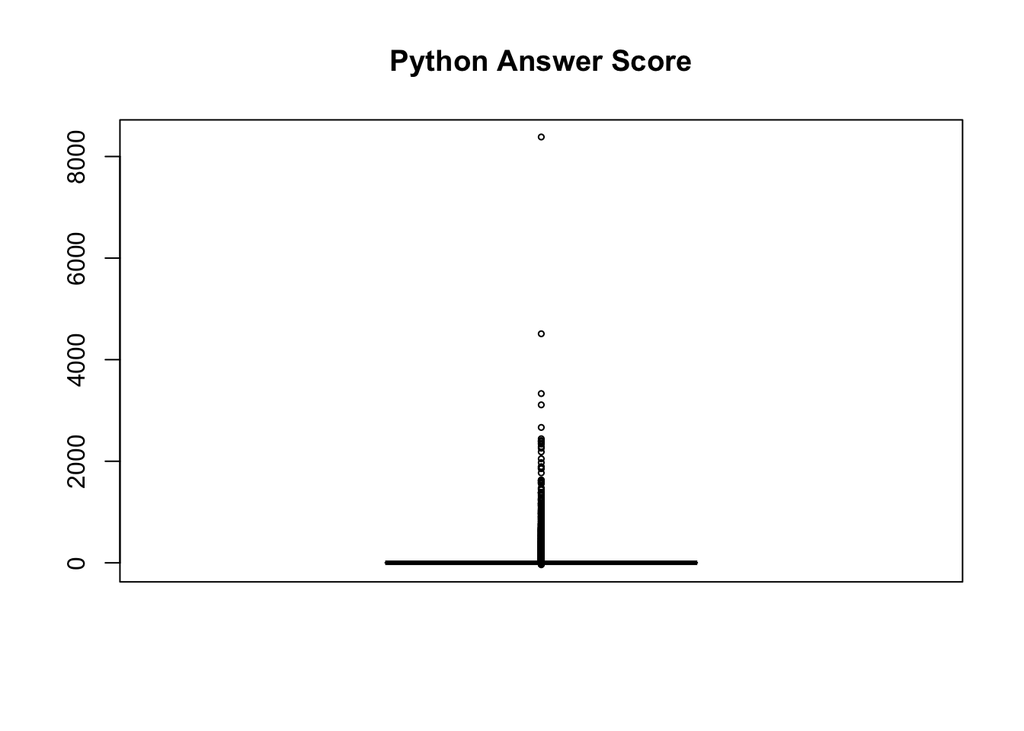

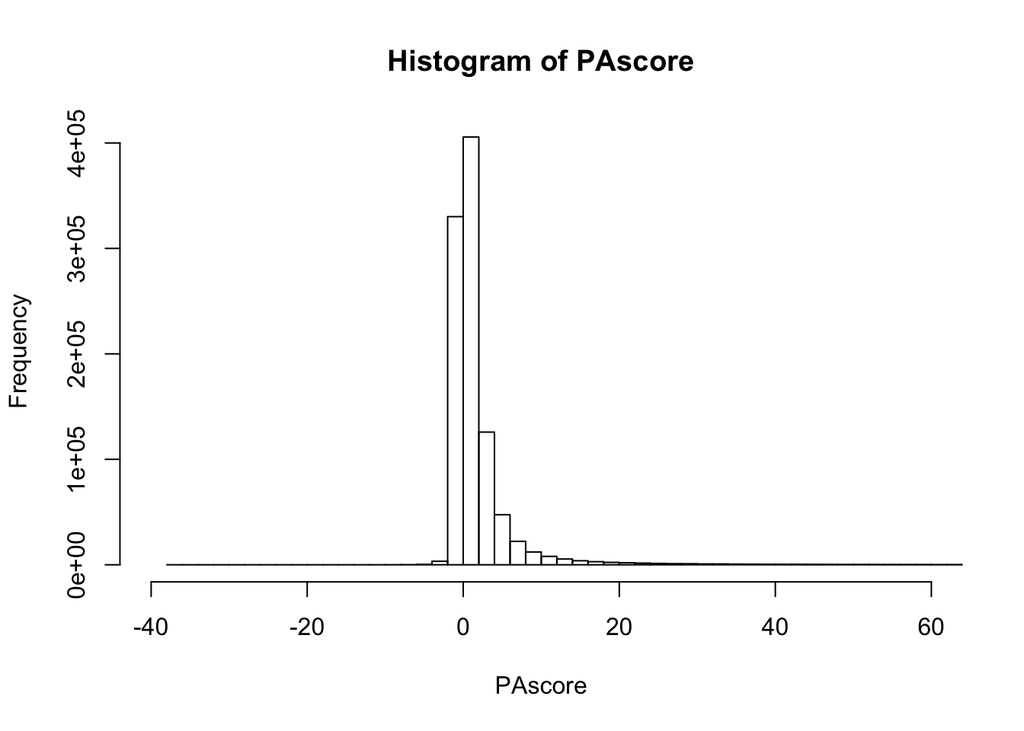

Choose the good answer threshold = 3, the 3rd quantile.

## Python Time EDA

Total number of questions is 607276. Number of questions with Time=0 is 429. Number of questions never get a good answer is 430177.

```
##    Min. 1st Qu.  Median    Mean 3rd Qu.    Max.
##     0.0    26.6  2212.0  1572.0  2212.0  2212.0
```

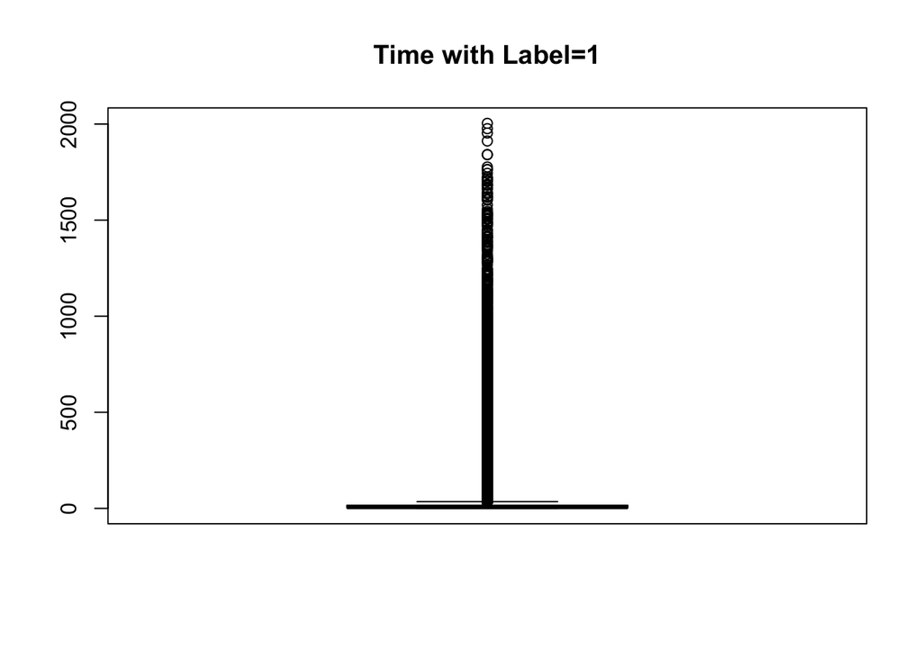

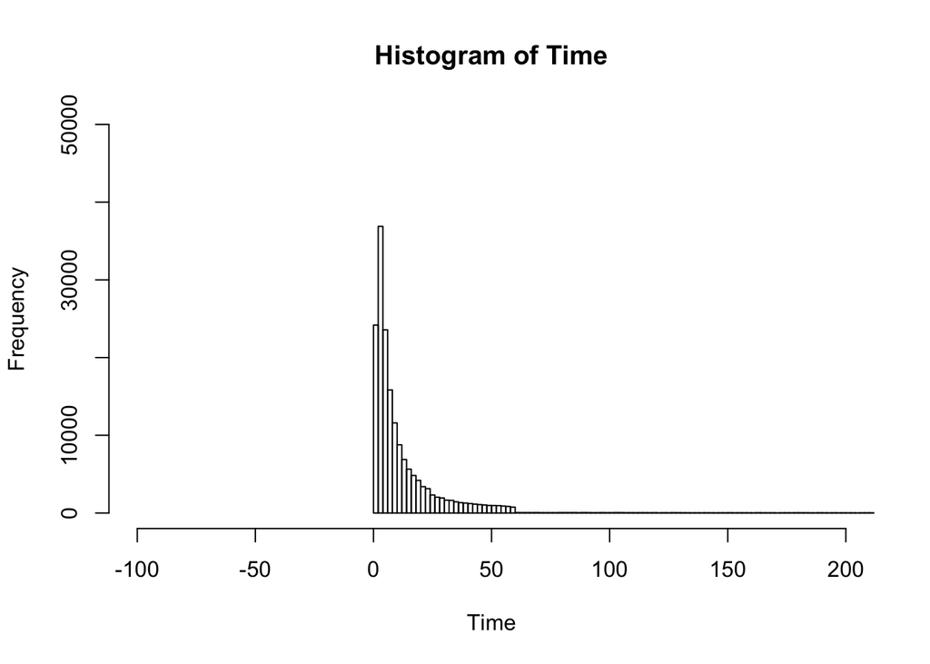

## Random Forest

Score ~ tag_count + max_tag_freq + sum_tag_freq + body_length + title_length + body_word_count + title_word_count + code_blocks_count + code_comments_count + url_count + img_count + code_length + comments_length

MSE = 19.1

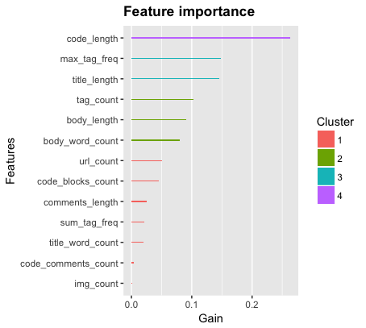

## Logistic Regression

Label prediction: Split data into train(80%) and test(20%), do logistic regression, calculate prediction accuracy.

```
##               Estimate  Std. Error   z value Pr(>|z|)
## (Intercept) -1.7462727 0.004808411 -363.1704        0
## Score        0.5649856 0.002307515  244.8459        0
```

Prediction Accuracy = 0.7923346